# Figure S3

Script to regenerate figure S3, the MOI estimation boxplot of scenario 2, after merging similar strains (similarity >= 92/96) for each host.

Load the data frame needed to generate the figures. The data frame includes true and inferred MOI for each host after merging similar strains, in 128 runs for each method under each scenario.

The columns of MOI_combine represent true MOI, inferred MOI, inference method, error in MOI (inferred-true), and class of input data (read counts or categorical data).

```r
library(tidyverse)
library(ggthemes)

load("figureS3.Rdata")
head(MOI_combine)
```

|  | true_MOI | inferred_MOI | method | error | class |
| --- | --- | --- | --- | --- | --- |
| 1 | 1 | 1 | SS-Pois | 0 | Read counts |
| 2 | 1 | 1 | SS-Pois | 0 | Read counts |
| 3 | 1 | 1 | SS-Pois | 0 | Read counts |
| 4 | 1 | 1 | SS-Pois | 0 | Read counts |
| 5 | 1 | 1 | SS-Pois | 0 | Read counts |
| 6 | 1 | 1 | SS-Pois | 0 | Read counts |

Since the maximum MOI can be larger than 10, for better visualization, we set an upper threshold value of true MOI shown in the figure. The hosts with true MOI >=8 are combined into the same group.

```r
nhost=200 #Number of hosts
MCMC_rep=128 #Number of replicates in SNP-Slice and DEploid
McCOIL_rep=128 #Number of replicates in McCOIL

max_true_MOI<-8 # The upper threshold value of true MOI shown in the figure. The hosts with true MOI >=8 are put in the same group.
MOI_combine$true_MOI[MOI_combine$true_MOI>max_true_MOI]=max_true_MOI
xtick_group<-c(as.character(1:(max_true_MOI-1)),paste(">=",max_true_MOI,sep=""))
```

Count the number of hosts in each group of true_MOI, which will be printed in the x axis labels. Since the true MOI information in each MCMC replicate for each method is constant, here we count in RM-Prop and finally divide by the number of replicates.

```r
#Count the number of hosts in each group of true_MOI
MOI_group_counts<-as.data.frame(MOI_combine %>% group_by(true_MOI,method) %>% summarise (count=n()))
MOI_group_counts<-MOI_group_counts[MOI_group_counts$method=="RM-Prop",]
MOI_group_counts$count=MOI_group_counts$count/McCOIL_rep
```

Take 5% sub-groups in each method to be plooted out as points, for better visualization.

```r
MOI_snpSlice<-MOI_combine[MOI_combine$method %in% paste("SS",c("Pois","NegBin","Bin","Cat"),sep="-"),]
MOI_McCOIL<-MOI_combine[MOI_combine$method %in% paste("RM",c("Prop","Cat"),sep="-"),]
MOI_DEploid<-MOI_combine[MOI_combine$method=="DEploid",]
MOI_snpSlice_sub<-as.data.frame(MOI_snpSlice %>% group_by(method) %>% sample_n(nhost*MCMC_rep*0.05))
MOI_McCOIL_sub<-as.data.frame(MOI_McCOIL %>% group_by(method) %>% sample_n(nhost*McCOIL_rep*0.05))
MOI_DEploid_sub<-as.data.frame(MOI_DEploid %>% group_by(method) %>% sample_n(nhost*MCMC_rep*0.05))
MOI_combine_sub<-rbind(MOI_snpSlice_sub,MOI_McCOIL_sub,MOI_DEploid_sub)
```

Plotting figure S3.

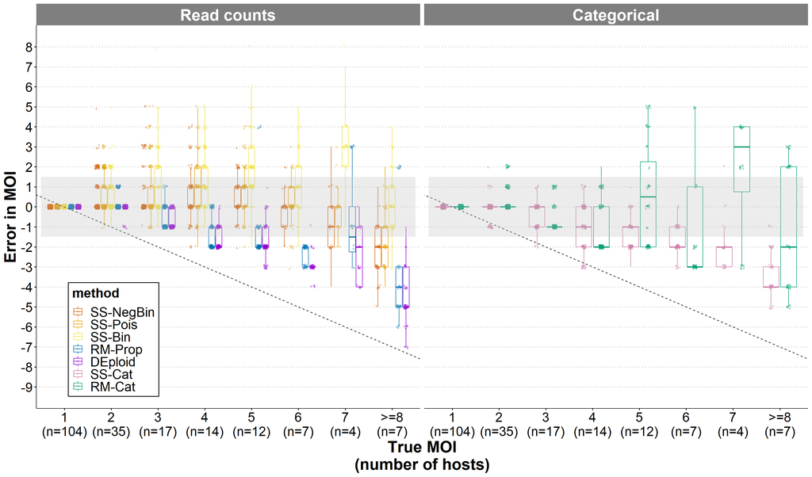

```r
color<-c("SS-NegBin"="#D55E00","SS-Pois"="#E69F00","SS-Bin"="#F0E442","SS-Cat"="#CC79A7","RM-Prop"="#0072B2","RM-Cat"="#009E73","DEploid"="#9400D3")

box<-ggplot(MOI_combine,aes(x=as.factor(true_MOI),y=error,color=method))+theme_bw()+xlab(paste("True MOI","(number of hosts)",sep="\n"))+ylab("Error in MOI")+theme_clean()+
  geom_boxplot(outlier.shape = NA)+
  geom_point(data=MOI_combine_sub,aes(x=as.factor(true_MOI),y=error,color=method),size=1,position=position_jitterdodge(jitter.height=0.1),alpha=0.3)+
  scale_x_discrete(breaks=as.character(1:max_true_MOI),labels=paste(xtick_group,paste("(n=",MOI_group_counts$count,")",sep=""),sep="\n") )+
  theme(plot.title=element_text(size=24,face="bold"), axis.text=element_text(size=20),
        axis.title=element_text(size=24,face="bold"), legend.title=element_text(size=20,face="bold"),plot.background = element_blank(),
        legend.text=element_text(size=20),legend.position=c(0.1,0.18),legend.key = element_rect(fill='transparent'),
        strip.background =element_rect(fill="grey50"),strip.text = element_text(colour = 'white'))+
  #Error will not be less than 1-true_MOI since inferred_MOI will not be <1
  geom_abline(slope=-1,intercept=1,linetype="dashed")+
  scale_color_manual(values=color)+scale_y_continuous(limits=c(-9.2,8.2),breaks=seq(-9,8,1))+
  #Shade the region of -1<=Error<=1
  annotate(geom = "rect", xmin = 0.5, xmax = max_true_MOI+0.5, ymin = -1.5, ymax = 1.5, fill = "grey", linetype=0, alpha = 0.3)+
  facet_grid(. ~ class)+theme(strip.text.x = element_text(size=24,face="bold"))
box
```